# Yelp Review

# Overview

```r
pacman::p_load(jsonlite)
yelp_data <- jsonlite::stream_in(file("yelp_review_20k.json"), verbose = F)
#str(yelp_data)

# different JSON format
# tmp_json <- toJSON(yelp_data[1:10,])
# fromJSON(tmp_json)
```

```r
yelp_data <- yelp_data %>% mutate(year = year(date)) %>% mutate(month = month(date)) %>% mutate (day = day(date)) %>% mutate(weekday = wday(date, label=TRUE, abbr=FALSE)) %>% mutate(fMonth = as.factor(month)) %>% mutate(fDay = as.factor(day))
```

```r
min(yelp_data$date)
```

```
## [1] "2004-10-19 03:05:42"
```

```r
max(yelp_data$date)
```

```
## [1] "2018-10-04 18:20:45"
```

No, partial f-test below shows that, controlling for year, both month of the year and days of the week are not significant at 0.05 level in determining the number of stars a review has.

```r
fit.eda.1 <- lm(stars ~ year, data = yelp_data)
fit.eda.2 <- lm(stars ~ year + fMonth, data = yelp_data)
anova(fit.eda.1, fit.eda.2)
```

```
## Analysis of Variance Table
##
## Model 1: stars ~ year
## Model 2: stars ~ year + fMonth
##   Res.Df   RSS Df Sum of Sq      F Pr(>F)
## 1  19997 42319
## 2  19986 42295 11    24.079 1.0344 0.4122
```

```r
fit.eda.3 <- lm(stars ~ year + weekday, data = yelp_data)
anova(fit.eda.1, fit.eda.3)
```

```
## Analysis of Variance Table
##
## Model 1: stars ~ year
## Model 2: stars ~ year + weekday
##   Res.Df   RSS Df Sum of Sq      F Pr(>F)
## 1  19997 42319
## 2  19991 42299  6    19.752 1.5558 0.1557
```

Extract document term matrix for texts to keep words appearing at least .5% of the time among all 20000 documents. Go through the similar process of cleansing as we did in the lecture.

```r
data.text <- yelp_data$text
mycorpus1 <- VCorpus(VectorSource(data.text))
```

```r
# Converts all words to lowercase
mycorpus_clean <- tm_map(mycorpus1, content_transformer(tolower))

# Removes common English stopwords (e.g. "with", "i")
mycorpus_clean <- tm_map(mycorpus_clean, removeWords, stopwords("english"))

# Removes any punctuation
# NOTE: This step may not be appropriate if you want to account for differences
#       on semantics depending on which sentence a word belongs to if you end up
#       using n-grams or k-skip-n-grams.
#       Instead, periods (or semicolons, etc.) can be replaced with a unique
#       token (e.g. "[PERIOD]") that retains this semantic meaning.
mycorpus_clean <- tm_map(mycorpus_clean, removePunctuation)

# Removes numbers
mycorpus_clean <- tm_map(mycorpus_clean, removeNumbers)

# Stem words
mycorpus_clean <- tm_map(mycorpus_clean, stemDocument, lazy = TRUE)
```

```r
dtm1 <- DocumentTermMatrix(mycorpus_clean)
```

```r
threshold <- .005*length(mycorpus_clean)   # .5% of the total documents = .005 of the total documents
words.1 <- findFreqTerms(dtm1, lowfreq=threshold)
dtm2<- DocumentTermMatrix(mycorpus_clean, control = list(dictionary = words.1))
dim(dtm2)
```

```
## [1] 19999  1461
```

This matrix records the frequency of each selected word at each yelp review review. The cell number at row 100 and column 405 is 0. The 0 represents the number of times the word ‘driver’ appears in review associated with row 100 (driver is the word associated with column 405).

```r
inspect(dtm2[100,405])
```

```
## <<DocumentTermMatrix (documents: 1, terms: 1)>>
## Non-/sparse entries: 0/1
## Sparsity           : 100%
## Maximal term length: 6
## Weighting          : term frequency (tf)
## Sample             :
##      Terms
## Docs  driver
##   100      0
```

Inspect(dtm2) shows a 98% sparsity, which means 98% of the cells of the dataframe/ elements of the matrix has ‘0’ as value.

```r
inspect(dtm2)
```

```
## <<DocumentTermMatrix (documents: 19999, terms: 1461)>>
## Non-/sparse entries: 707063/28511476
## Sparsity           : 98%
## Maximal term length: 13
## Weighting          : term frequency (tf)
## Sample             :
##        Terms
## Docs    food get good great just like order place servic time
##   10892    3   0    3     3    3    3     2     0      0    0
##   12262    2   4    0     0    2    4     4     1      2    3
##   16453    2   2    4     2    7    6     7     5      0    5
##   1755     0  10    0     0    0    2     1     1      4    7
##   230      5   4    1     0    5    6    17     0      1    7
##   258      0   3    3     2    6    2     0     1      0    2
##   3563     0   3    1     0    4    2     0     0      0    5
##   7164     5   2    8     2    4    5     4     6      0    1
##   8357     1   2    4     1    4    2     4     1      2    3
##   9106     8   5    3     1    3    2     3     1      3    3
```

3. Set the stars as a two category response variable called rating to be “1” = 5,4 and “0”= 1,2,3. Combine the variable rating with the dtm as a data frame called data2.

```r
yelp_data <- yelp_data %>% mutate(rating = ifelse(stars >3, 1, 0))
```

```r
rating <- yelp_data$rating
data2 <- cbind(dtm2, rating)
data2 <- data.frame(as.matrix(data2))
data2 <- data2 %>% rename(rating = V1462)

#data2[,1461:1462]
```

## Analysis

Get a training data with 13000 reviews and the 5000 reserved as the testing data. Keep the rest (2000) as our validation data set.

```r
set.seed(1)
n <- nrow(data2)
train.index <- sample(n, 13000)
data2.train <- data2[train.index,]
data2.leftover <- data2[-train.index,]

dim(data2.train)
```

```
## [1] 13000  1462
```

```r
dim(data2.leftover)
```

```
## [1] 6999 1462
```

```r
set.seed(1)
n.leftover <- nrow(data2.leftover)
test.index <- sample(n.leftover, 5000)

data2.test <- data2.leftover[test.index,]
data2.validate <- data2.leftover[-test.index,]

dim(data2.test)
```

```
## [1] 5000 1462
```

```r
dim(data2.validate)
```

```
## [1] 1999 1462
```

## 2. LASSO

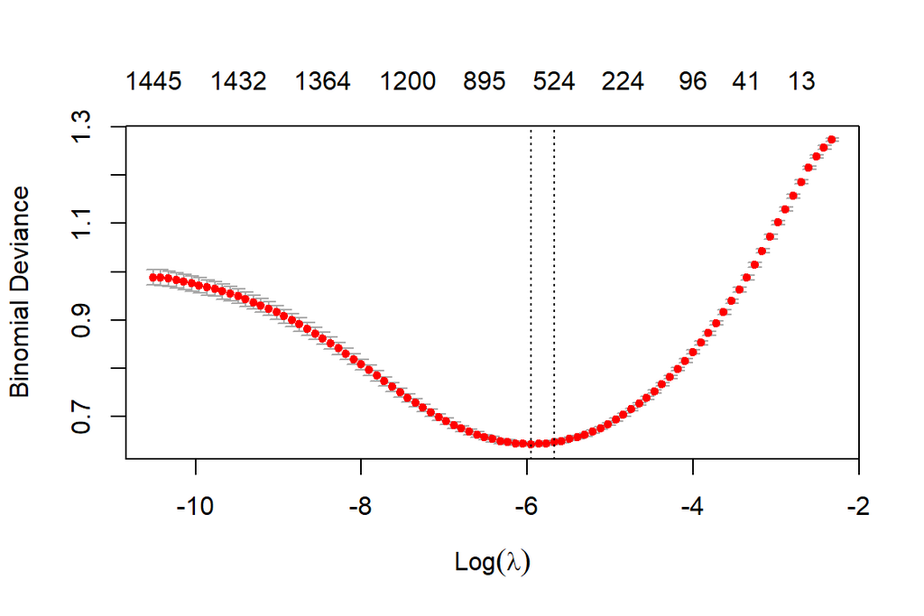

```r
y <- data2.train$rating
#data2.train$rating
X1 <- sparse.model.matrix(rating~., data=data2.train)[, -1]

set.seed(1)
result.lasso <- cv.glmnet(X1, y, alpha=1, family="binomial")
plot(result.lasso)
```

```r
coef.1se <- coef(result.lasso, s="lambda.1se")
coef.1se <- coef.1se[which(coef.1se !=0),]
lasso.words <- rownames(as.matrix(coef.1se))[-1]
summary(lasso.words)
```

```
##    Length     Class      Mode
##       524 character character
```

The two leading words are ‘bomb’ and ‘cheesi’, with coefficients 2.60 and 2.37 respectively. The positive coefficients indicate that having these two words in a review makes it more likely that the review is a positive one.

```r
sel_cols <- c("rating", lasso.words)

data_sub <- data2.train %>% select(all_of(sel_cols))
result.glm <- glm(rating~., family=binomial, data_sub)
```

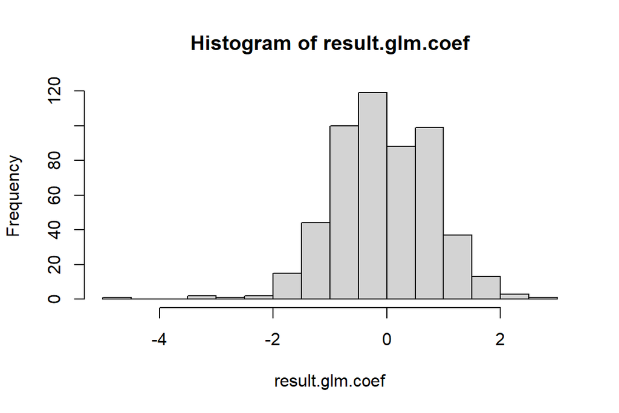

```r
result.glm.coef <- coef(result.glm)
hist(result.glm.coef)
```

```r
coef_df <- data.frame(result.glm.coef)
coef_df <- coef_df %>% arrange(desc(result.glm.coef))
coef_df <- coef_df %>% mutate(rank = row_number())
coef_df
```

```
##              result.glm.coef rank
## bomb              2.60533368    1
## cheesi            2.37355800    2
## thorough          2.24379968    3
## gem               2.06248496    4
## met               1.89264069    5
## awesom            1.87266167    6
## heaven            1.84599048    7
## futur             1.83902479    8
## outstand          1.81460855    9
## pleasur           1.70183106   10
## stage             1.69358929   11
## delici            1.63282389   12
## random            1.60747804   13
## refresh           1.57698773   14
## delight           1.56424295   15
## fabul             1.54243451   16
## amaz              1.52553598   17
## phenomen          1.48378821   18
## yum               1.45742710   19
## savori            1.43356412   20
## japanes           1.37197978   21
## within            1.35797392   22
## assist            1.35775852   23
## stress            1.34671715   24
## notch             1.32386881   25
## refer             1.30788768   26
## mine              1.29857265   27
## feet              1.26020598   28
## banana            1.23553683   29
## wood              1.23424752   30
## excel             1.22792619   31
## prompt            1.21544314   32
## whenev            1.20927307   33
## die               1.20878660   34
## suit              1.18451787   35
## unlik             1.18160989   36
## accommod          1.17389930   37
## program           1.16323667   38
## beverag           1.15809790   39
```

[output cut: 471 more lines]

```
## rude             -1.75424778  511
## poor             -1.77666364  512
## bland            -1.81106134  513
## perhap           -1.82996663  514
## lack             -1.83883918  515
## properti         -1.86936478  516
## wors             -1.96204395  517
## meh              -1.97217893  518
## ruin             -1.97281920  519
## worst            -2.33337685  520
## mediocr          -2.37644164  521
## ignor            -2.53469187  522
## disgust          -3.19854735  523
## horribl          -3.36199927  524
## unprofession     -4.74825413  525
```

Make a word cloud with the top 100 positive words according to their coefficients. Interpret the cloud briefly.

```r
good.glm <- result.glm.coef[which(result.glm.coef > 0)]
good.glm <- good.glm[-1]  # took intercept out
names(good.glm)[1:20]  # which words are positively associated with good ratings
```

```
##  [1] "abl"      "access"   "accommod" "afford"   "air"      "also"
##  [7] "alway"    "amaz"     "american" "appreci"  "approach" "assist"
## [13] "attent"   "authent"  "awesom"   "balanc"   "ball"     "banana"
## [19] "basil"    "beat"
```

```r
good.fre <- sort(good.glm, decreasing = TRUE) # sort the coef's
round(good.fre, 4)[1:20] # leading 20 positive words, amazing!
```

```
##     bomb   cheesi thorough      gem      met   awesom   heaven    futur
##   2.6053   2.3736   2.2438   2.0625   1.8926   1.8727   1.8460   1.8390
## outstand  pleasur    stage   delici   random  refresh  delight    fabul
##   1.8146   1.7018   1.6936   1.6328   1.6075   1.5770   1.5642   1.5424
##     amaz phenomen      yum   savori
##   1.5255   1.4838   1.4574   1.4336
```

```r
length(good.fre)
```

```
## [1] 240
```

```r
# hist(as.matrix(good.fre), breaks=30, col="red")
good.word <- names(good.fre)

#length(good.word)
```

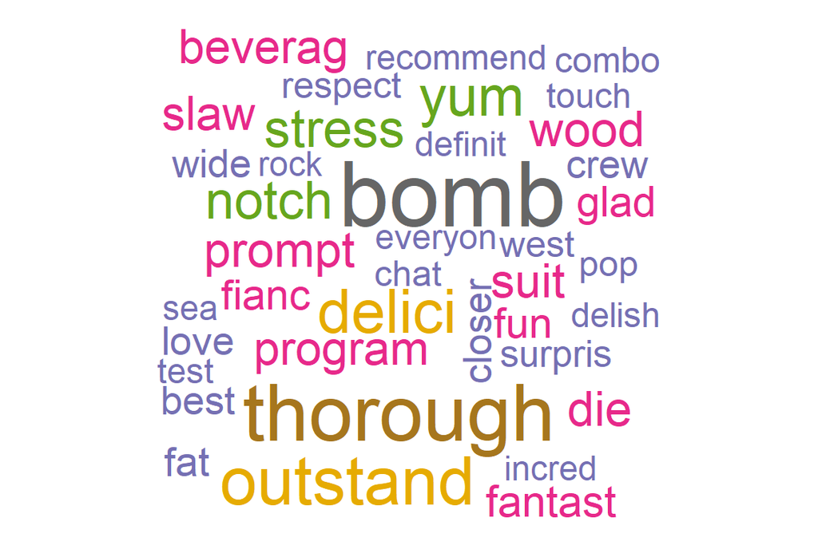

```r
cor.special <- brewer.pal(8,"Dark2")
wordcloud(good.word[1:100], good.fre[1:100], colors=cor.special, ordered.colors=F)
```

Repeat i) and ii) for the bag of negative words.

```r
bad.glm <- result.glm.coef[which(result.glm.coef < 0)]
cor.special <- brewer.pal(6,"Dark2")
bad.fre <- sort(-bad.glm, decreasing = TRUE)
```

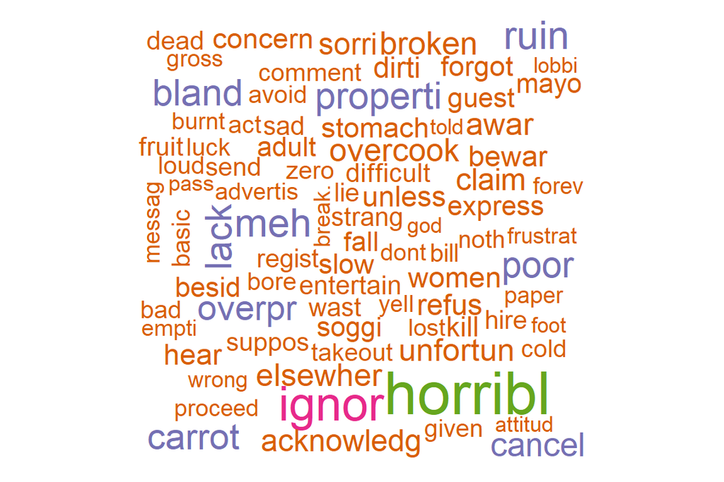

```r
bad.word <- names(bad.fre)
wordcloud(bad.word[1:100], bad.fre[1:100],color=cor.special, ordered.colors=F, min.freq = 100)
```

Some words are strongly associated with positive reviews whereas others, negative reviews. The negative words seem to indicate that a negative experience is a strong driver for a person to write a review - words such as “horrible”, “worst”, and “disgust” are expressive of the writer’s emotions.

Overall, the final list of positive and negative coefficient words makes sense. The words with positive coefficient are generally words with positive connotation such as “bomb”, “gem”, or “awesome” whereas words with negative coefficient are generally words with negative connotation such as “unprofessional”, “horrible”, “worst”, and “disgust.”

Using majority votes find the testing errors

1. From Lasso fit

```r
predict.lasso <- predict(result.lasso, as.matrix(data2.test[, -1]), type = "class", s="lambda.1se")
  # output majority vote labels

# LASSO testing errors
mean(data2.test$rating != predict.lasso)
```

```
## [1] 0.6194
```

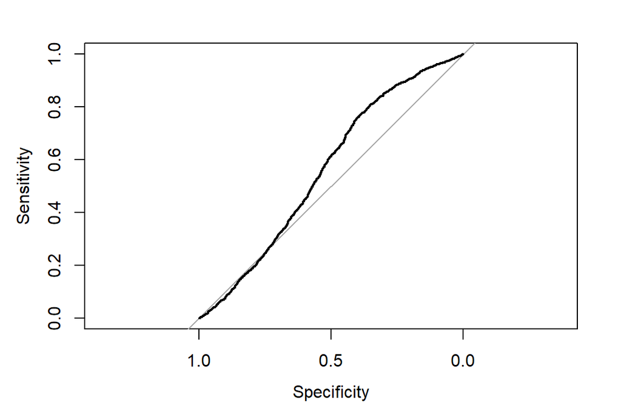

```
##
## Call:
## roc.default(response = data2.test$rating, predictor = predict.lasso.p,     plot = TRUE)
##
## Data: predict.lasso.p in 1708 controls (data2.test$rating 0) > 3292 cases (data2.test$rating 1).
## Area under the curve: 0.5616
```

```r
predict.lasso.p <- predict(result.lasso, as.matrix(data2.test[, -1]), type = "response", s="lambda.1se")

pROC::roc(data2.test$rating, predict.lasso.p, plot=TRUE)
```

2. From logistic regression

```r
predict.glm <- predict(result.glm, data2.test, type = "response")

# Majority vote
class.glm <- ifelse(predict.glm > .5, "1", "0")

testerror.glm <- mean(data2.test$rating != class.glm)
testerror.glm
```

```
## [1] 0.1338
```

Logistic regression has smaller errors.

## 3. Random Forest

In Random Forest we first take sets of bootstrap samples. We then use each set of samples to build a decision tree - one tree per set of bootstrap samples. Each tree is limited to be built from a subset of the original predictors, and the number of predictors in the subset is predetermined through a parameter ‘mtry.’ We then ‘bag’ the trees by taking the average of the predictions of all the trees.

We first fit a random forest model with 10 mtry’s and 300 ntrees. From the initial plot we see that 100 trees is a reasonable point to start, as there isn’t much difference in errors between 200 trees and 100 trees.

We then tune the mtry, seeing the errors at different mtry’s by fiting a random forest model using the ranger package and collecting the errors based on 100 ntrees. We see in the plot that testing errors seem to flatten between 40 and 50 mtry’s so we select 45 as the number of mtrys.

The final set of hyperparameters is (ntree= 100, mtry=45). Using these and majority vote criteria, final testing error equals 0.1544.

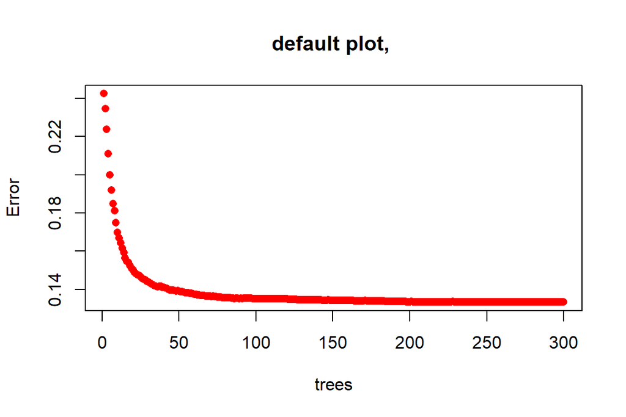

```r
set.seed(1)
fit.rf <- randomForest(rating~., data2.train, mtry=10, ntree=300)
plot(fit.rf, col="red", pch=16, type="p", main="default plot, ")
```

```r
rf.error.p <- 1:50
for (p in 1:50)
{
  fit.rf.ranger.p <- ranger::ranger(rating~., data2.train, num.trees = 100, mtry = p, importance="impurity")
  rf.error.p[p] <- fit.rf.ranger.p$prediction.error
}
rf.error.p
```

```
##  [1] 0.1937114 0.1672334 0.1581630 0.1516057 0.1472055 0.1444659 0.1415021
##  [8] 0.1373610 0.1357269 0.1358931 0.1352741 0.1328480 0.1319376 0.1314284
## [15] 0.1304176 0.1305760 0.1284999 0.1287825 0.1275339 0.1272204 0.1264473
## [22] 0.1267533 0.1262437 0.1264717 0.1262909 0.1243031 0.1247362 0.1242130
## [29] 0.1234101 0.1244546 0.1230647 0.1226859 0.1230046 0.1232016 0.1220910
## [36] 0.1228695 0.1228663 0.1217041 0.1219311 0.1222730 0.1218606 0.1220746
## [43] 0.1224506 0.1219639 0.1217991 0.1226251 0.1215744 0.1217559 0.1214099
## [50] 0.1213055
```

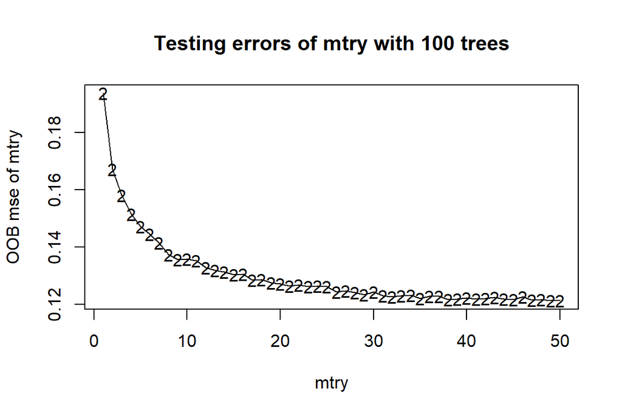

```r
plot(1:50, rf.error.p, pch=50,
     main = "Testing errors of mtry with 100 trees",
     xlab="mtry",
     ylab="OOB mse of mtry")
lines(1:50, rf.error.p)
```

```r
set.seed(1)
fit.rf.ranger <- ranger::ranger(rating~., data2.train, num.trees = 100, mtry = 45, importance="impurity")
fit.rf.ranger$prediction.error
```

```
## [1] 0.1215985
```

```r
imp <- importance(fit.rf.ranger)
imp[order(imp, decreasing = T)][1:20]
```

```
##     great      rude      love      amaz   horribl      told    delici       ask
##  75.79688  41.20677  39.30624  39.16678  38.80307  36.46877  34.98710  31.65536
##     worst      said       bad      noth     order      best    awesom   definit
##  29.24383  27.61646  27.02508  26.98440  26.29059  23.94062  20.74784  19.80797
## recommend      poor    friend   terribl
##  18.80526  17.68622  17.25055  17.03091
```

```r
predict.rf <- predict(fit.rf.ranger, data=data2.test, type="response")
class.rf <- data.frame(predict.rf$predictions)

# majority vote
class.rf <- class.rf %>% mutate(prediction = ifelse(predict.rf.predictions > .5, "1", "0"))
mean(data2.test$rating != class.rf$prediction)
```

```
## [1] 0.1544
```

take 750 PC’s as it explains roughly 75% of the variance of the original dataset.

```r
pc.train <- prcomp(data2.train[, -c(1)], scale=TRUE)
pc.train.scores <- pc.train$x
```

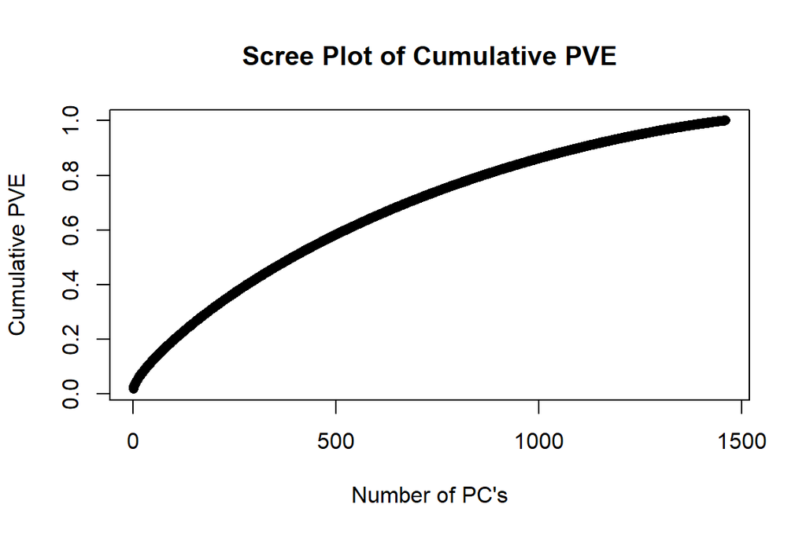

```r
plot(summary(pc.train)$importance[3, ], pch=16,
  ylab="Cumulative PVE",
  xlab="Number of PC's",
  main="Scree Plot of Cumulative PVE")
```

```r
#summary(pc.train)$importance[3, 750]
#summary(pc.train)
```

```r
# we select 750 principal components to build the model
pc.train.750 <- pc.train.scores[, c(1:750)]
pc.train.750 <- data.frame(pc.train.750) %>% mutate(rating = data2.train$rating)
#dim(pc.train.750)
```

```r
set.seed(1)
fit.rf.ranger.pc <- ranger::ranger(rating~., pc.train.750, num.trees = 100, mtry = 45, importance="impurity")
fit.rf.ranger.pc$prediction.error
```

```
## [1] 0.1298769
```

```r
imp <- importance(fit.rf.ranger.pc)
imp[order(imp, decreasing = T)][1:20]
```

```
##       PC3       PC4       PC5      PC19       PC2       PC8      PC16       PC1
## 235.75221 185.36952 122.50885 105.42833  60.81753  41.53517  34.91589  32.89949
##      PC39      PC31      PC17       PC7      PC13      PC11      PC79      PC12
##  27.21286  22.74596  20.45570  19.78369  16.94317  16.01811  12.58686  12.22115
##      PC33      PC21      PC46      PC32
##  10.97856  10.26860  10.01368   9.90243
```

The testing error is 0.4288, which is worse than 0.1544 obtain using original inputs.

```r
pc.test <- prcomp(data2.test[, -c(1)], scale=TRUE)
pc.test.scores <- pc.test$x
```

```r
# we select 750 principal components to test
pc.test.750 <- pc.test.scores[, c(1:750)]
pc.test.750 <- data.frame(pc.test.750) %>% mutate(rating = data2.test$rating)
```

```r
predict.rf.pc <- predict(fit.rf.ranger.pc, data=pc.test.750, type="response")
class.rf.pc <- data.frame(predict.rf.pc$predictions)

# majority vote
class.rf.pc <- class.rf.pc %>% mutate(prediction = ifelse(predict.rf.pc.predictions > .5, "1", "0"))
mean(pc.test.750$rating != class.rf.pc$prediction)
```

```
## [1] 0.4288
```

## 6. Ensemble model

Take the average of the predictions generated by the logistic regression model and the random forest models, and applied majority vote. The ensemble’s test error is 0.1264.

```r
ensemble <- data.frame(cbind (predict.glm, predict.rf$predictions))
ensemble <- ensemble %>% rename(predict.rf = V2)
ensemble <- ensemble %>% rowwise() %>%
    mutate(average =mean(c(predict.glm, predict.rf)))
```

```r
ensemble <- ensemble %>% mutate(prediction = ifelse(average > .5, "1", "0"))
mean(data2.test$rating != ensemble$prediction)
```

```
## [1] 0.1264
```